# Prediction Assignment

Alan M. Rathbun

April 20, 2017

#### Objective

- The aim of this analysis was to develop a prediciton function to discriminate between how well individuals peform a specific physical activity.

#### Data Source

- Data for this analysis came from the publically available Weight Lifting Exercise (WLE) cohort (http://groupware.les.inf.puc-rio.br/har). The dataset was intended to define the quality of execution of human physical activity using an on-body sensing approach.

#### Analytic Sample

- The sample for analysis comprised six young healthy participants who were required to do a physical performance task while wearing activity recognition monitors and under supervision of an experienced weight lifter. Participants were males between the ages of 20 to 28 years old and had little weighting lifting experience. The training dataframe was partitioned in to separate training (80%) and validation (20%) samples.

#### Outcome Variable

- Study participants performed unilateral dumbbell bicep curls in five different ways in a single set of ten repetitions. Outcome levels included five different performance specifications: exactly according to specification (Class A), throwing elbows to the front (Class B), lifting the dumbbell only halfway (Class C), lowering the dumbbell only halfway (Class D), and throwing the hips to the front (Class E).

#### Predictors

- Variables used as potential predictors included all those unique data features obtained from activity recognition monitors that captured physical peformance information (location, acceleration, etc.).

#### Statistical Analysis

- A data driven approach was used to create a predition function intended to correctly classify physical activity specifications from on-body sensor information. First, training set variables were initially screened using classification and regression trees (CART) to identify those features that contributed variance to the prediction model. Second, a bagged CART appproach with 10-fold cross validation was used to develop a final prediction function using the screened variables. Accuracy of the prediction function was assessed using a confusion matrix comparing the observed outcomes to the predicted outcomes obtained from the final model. Accuracy of the prediction function was calculated in the training sample versus validation sample to obtain an estimate of the out-of-sample error.

#### Load dependencies

- Downloader package
- Caret package
- Party package
- Party kit package

#### Load in data frame

```
## [1] 19622   160
```

* Training dataframe includes 19,622 observations with 160 variables

#### Subset dataframe to columns without missing data and relavent features for prediction

```
## [1] 19622    53
```

* Training dataframe has been reduced to 53 variables (52 predictors and 1 outcome) for observations with complete data

#### Split training dataframe into training set and validation set

* Original training dataframe has been subset into a training set with 15699 observations and a validation sample with 3147 observations

#### Train initial prediction function using classification and regression trees and identify potential predictor variables

```
## rpart variable importance
##
##   only 20 most important variables shown (out of 52)
##
##                   Overall
## pitch_forearm      100.00
## roll_forearm        71.26
## roll_belt           69.86
## magnet_dumbbell_y   49.01
## accel_belt_z        42.83
## yaw_belt            40.22
## magnet_belt_y       39.03
## total_accel_belt    35.16
## magnet_arm_x        27.63
## accel_arm_x         26.45
## roll_dumbbell       19.10
## magnet_dumbbell_z   17.92
## magnet_dumbbell_x   17.71
## accel_dumbbell_y    16.24
## roll_arm            14.92
## accel_belt_x         0.00
## accel_dumbbell_z     0.00
## accel_forearm_y      0.00
## accel_dumbbell_x     0.00
## magnet_arm_z         0.00
```

* Variables with variance contribution to initial prediction model include: pitch_forearm, roll_forearm, roll_belt, magnet_dumbbell_y, accel_belt_z, magnet_belt_y, yaw_belt, magnet_dumbbell_z, total_accel_belt, magnet_arm_x, accel_arm_x, roll_dumbbell, accel_dumbbell_y, roll_arm

#### Visualize most important variables with shallow tree

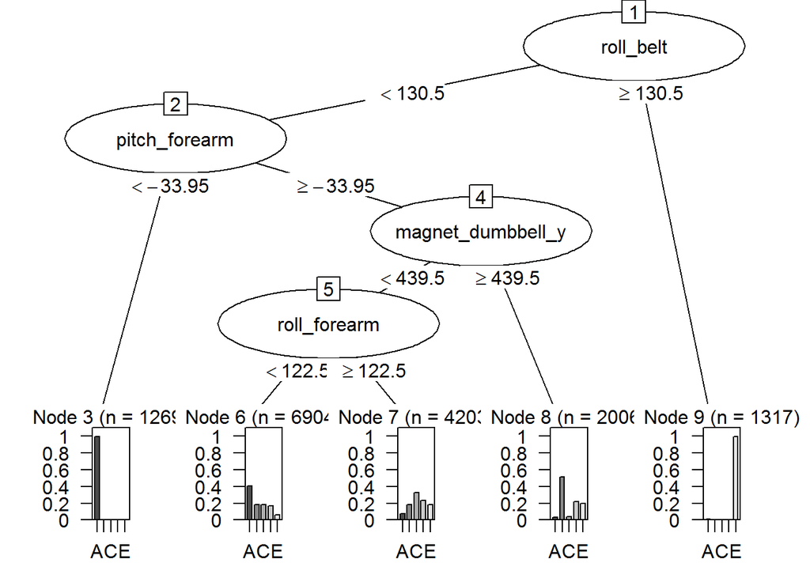

#### Train prediction function using screened variables and bagged classification and regression trees with 10-fold cross-validation

```
## Bagged CART
##
## 15699 samples
##    14 predictor
##     5 classes: 'A', 'B', 'C', 'D', 'E'
##
## No pre-processing
## Resampling: Cross-Validated (10 fold)
## Summary of sample sizes: 14129, 14130, 14128, 14130, 14130, 14129, ...
## Resampling results:
##
##   Accuracy   Kappa
##   0.9792342  0.9737352
##
##
```

#### Calcuate accuracy of prediction function on training sample

```
## Confusion Matrix and Statistics
##
##           Reference
## Prediction    A    B    C    D    E
##          A 4464    0    0    0    0
##          B    0 3038    0    0    0
##          C    0    0 2738    0    0
##          D    0    0    1 2572    0
##          E    0    0    0    0 2886
##
## Overall Statistics
##
##                Accuracy : 0.9999
##                  95% CI : (0.9996, 1)
##     No Information Rate : 0.2843
##     P-Value [Acc > NIR] : < 2.2e-16
##
##                   Kappa : 0.9999
##  Mcnemar's Test P-Value : NA
##
## Statistics by Class:
##
##                      Class: A Class: B Class: C Class: D Class: E
## Sensitivity            1.0000   1.0000   0.9996   1.0000   1.0000
## Specificity            1.0000   1.0000   1.0000   0.9999   1.0000
## Pos Pred Value         1.0000   1.0000   1.0000   0.9996   1.0000
## Neg Pred Value         1.0000   1.0000   0.9999   1.0000   1.0000
## Prevalence             0.2843   0.1935   0.1745   0.1638   0.1838
## Detection Rate         0.2843   0.1935   0.1744   0.1638   0.1838
## Detection Prevalence   0.2843   0.1935   0.1744   0.1639   0.1838
## Balanced Accuracy      1.0000   1.0000   0.9998   1.0000   1.0000
```

* Accuracy of the final prediction model at classifying individuals within the training set is 99.99%, which is almost perfect prediction

#### Calculate accuracy of prediction function on validation sample and assess out-of-sample error

```
## Confusion Matrix and Statistics
##
##           Reference
## Prediction   A   B   C   D   E
##          A 893   0   0   0   0
##          B   0 610   0   0   0
##          C   0   0 537   0   0
##          D   0   0   0 521   0
##          E   0   0   0   0 586
##
## Overall Statistics
##
##                Accuracy : 1
##                  95% CI : (0.9988, 1)
##     No Information Rate : 0.2838
##     P-Value [Acc > NIR] : < 2.2e-16
##
##                   Kappa : 1
##  Mcnemar's Test P-Value : NA
##
## Statistics by Class:
##
##                      Class: A Class: B Class: C Class: D Class: E
## Sensitivity            1.0000   1.0000   1.0000   1.0000   1.0000
## Specificity            1.0000   1.0000   1.0000   1.0000   1.0000
## Pos Pred Value         1.0000   1.0000   1.0000   1.0000   1.0000
## Neg Pred Value         1.0000   1.0000   1.0000   1.0000   1.0000
## Prevalence             0.2838   0.1938   0.1706   0.1656   0.1862
## Detection Rate         0.2838   0.1938   0.1706   0.1656   0.1862
## Detection Prevalence   0.2838   0.1938   0.1706   0.1656   0.1862
## Balanced Accuracy      1.0000   1.0000   1.0000   1.0000   1.0000
```

* The accuracy of the prediction function in the validation sample is 100% (perfect prediction); slighty higher than the training set (99.9%). Out-of-sample classificaiton error is generally higher in validation samples, but in this case, the classification error is actually higher within the training set.

#### Predict outcomes using prediction function and testing dataframe

```
##  [1] B A B A A E D B A A B C B A E E A B B B
## Levels: A B C D E
```

#### References

- Velloso, E.; Bulling, A.; Gellersen, H.; Ugulino, W.; Fuks, H. Qualitative Activity Recognition of Weight Lifting Exercises. Proceedings of 4th International Conference in Cooperation with SIGCHI (Augmented Human ’13) . Stuttgart, Germany: ACM SIGCHI, 2013.